# Coursework - Data Science II

Justin Gusho, 222222837

For my coursework, I have chosen to undertake a classification problem using the Titanic dataset. The primary goal is to predict the survival outcomes (`yes or no`) based on some key variables which are believed to have an significant impact on the passengers´ chances of survival. Below, I explained the meaning for each of the variables.

# Dictionary

```r
##Variable            ##Description

#Survived               #The target variable. 0 = No, 1 = Yes

#Pclass                 #1 = First class, 2 = Second class, 3 = Third class

#Name                   #Name of each passenger

#Sex                    #0 = Female, 1 = Male

#Age                    #Age of each passenger

#SipSp                  #The number of siblings and spouses

#Parch                  #The number of parents and children

#Fare                   #The amount of money paid for the ticket from each passenger

#Ticket                 #The number of ticket

#Cabin                  #The number of the cabins where the passengers stayed

#Embarked                 #The place where the passengers embarked
```

`Survived` column is my target binary variable which indicates if the passengers survived or not. The ticket class is represented by `Pclass`. Whether the passengers stayed in *first*, *second* or *third* class likely have a significant impact on the rescue policies implemented after the accident.

I also believe that females were prioritized in the rescue efforts, so there is a lot to explore on the `Sex` variable as well.

The variables `SibSp` and `Parch` provide information about the family relationships of passengers. `SibSp` denotes the count of siblings (*brother*, *sister*) and spouses (*husband*, *wife*) that a passenger had aboard the Titanic. `Parch` denotes the count of parents and children that the passenger had aboard the Titanic.

This might be an interesting variable to study as analyzing `SibSp` and `Parch` in relation to `Survived` variable can reveal patterns regarding the importance of family relationships in survival outcomes during the Titanic disaster.

The `Embarked` variable incdicates the port of embarkation for each passenger whether they embarked in *Southampton*, *Cherbourg* or *Queenstown*.

# Data preperation

In this section I am preparing the dataset before I start with the modelling process. First of all, I am deleting 3 variables (`PassengerID`, `Ticket`, `Cabin`) that I think would not be useful for analysis. Then I use the *ìfelse* function in order to give the values 0 and 1 for the `Sex` column.

Next, I split the `Embarked` variable ( *Southampton*, *Cherbourg*, *Queenstown*) into 3 new columns to denote the port of embarkation. Each indicator is set to 1 if the passenger embarked from the corresponding port and 0 otherwise.

The `Pclass` variable (*1*, *2*, *3*) is similarly transformed into three binary indicators (`FirstClass`, `SecondClass`, `ThirdClass`) representing the ticket class. Each indicator is set to 1 if the passenger belongs to the respective ticket class and 0 otherwise.

Finally, I delete all the rows with *NA* values to ensure that my dataset is clean and ready for modelling.

```r
my_data[, c("PassengerId","Ticket", "Cabin") := NULL]


my_data$Sex <- ifelse(my_data$Sex == "male", 1, 0)


my_data$Southhampton <- ifelse(my_data$Embarked == "S", 1, 0)
my_data$Cherbourg <- ifelse(my_data$Embarked == "C", 1, 0)
my_data$Queenstown <- ifelse(my_data$Embarked == "Q", 1, 0)

my_data$FirstClass <- ifelse(my_data$Pclass == "1", 1, 0)
my_data$SecondClass <- ifelse(my_data$Pclass == "2", 1, 0)
my_data$ThirdClass <- ifelse(my_data$Pclass == "3", 1, 0)

my_data <- na.omit(my_data)


training_sample <- my_data[,sample(.N, floor(.N*.80))]
dt_training <- my_data[training_sample]
dt_test <- my_data[-training_sample]
```

# Visualization

In this section, I am performing some basic calculations for my dataset in order to bring some meaningful insights for the variables. We can see that the number of males passengers (*453*) is much larger then female passengers (*261*). This can also be a significant reason for the higher number of male fatalities.

Out of 714 observations in my dataset, only 290 survived the accident. Among them, 197 were females, while only 93 were males.

Next, I present some numbers to show the distribution of the passengers across each class and their survival rate. Interestingly, 122 out of 186 passengers who were staying in the *first class* survived. 83 out of 173 people in the *second class* survived and only 85 out of 355 people in the *third class* were rescued.

Furthermore, I am visualizing some graphs to illustrate the relationships between the variables. In the first figure I create a bar plot to show the distribution of males and females by the survival rate. We can once again notice that the number of males who survived was relatively low compared to the number of surviving females.

The next figure shows a box plot for the relationship of `Passenger fare` and `Survived`. It appears that passengers who paid more for their ticket seem to have a priority in the rescue policies during the titanic accident.

The other plot shows the distribution of `Passenger fare` by `Passenger class`. The data is much more spread for the *first class* compared to the other two classes.

In the last graph I create another bar plot, This time to show the relationship between `Survived` and `Passenger class`.

```r
#Number of females
sum(my_data$Sex == 0)
```

```
[1] 261
```

```r
#Number of males
sum(my_data$Sex == 1)
```

```
[1] 453
```

```r
#Amount of people who survived
sum(my_data$Survived == 1)
```

```
[1] 290
```

```r
#Amount of females who survived
sum(my_data$Sex == 0 & my_data$Survived == 1)
```

```
[1] 197
```

```r
#Amount of males who survived
sum(my_data$Sex == 1 &my_data$Survived == 1)
```

```
[1] 93
```

```r
#Amount of people in the first class
sum(my_data$FirstClass == 1)
```

```
[1] 186
```

```r
#Amount of people who survived in the first class
sum(my_data$FirstClass == 1 & my_data$Survived == 1)
```

```
[1] 122
```

```r
#Amount of  people in the second class
sum(my_data$SecondClass == 1)
```

```
[1] 173
```

```r
#Amount of people who survived in the second class
sum(my_data$SecondClass == 1 & my_data$Survived == 1)
```

```
[1] 83
```

```r
#Amount of people in the third class
sum(my_data$ThirdClass == 1)
```

```
[1] 355
```

```r
#Amount of people who survived in the third class
sum(my_data$ThirdClass == 1 & my_data$Survived == 1)
```

```
[1] 85
```

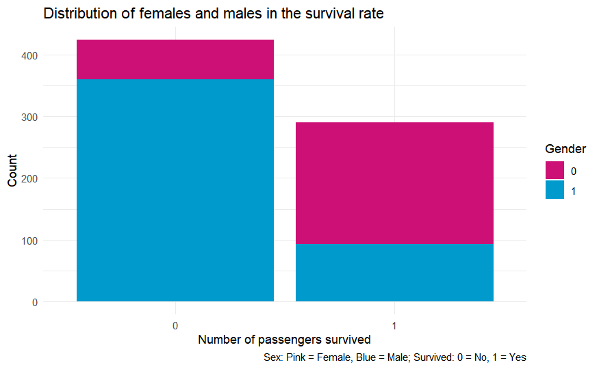

```r
#Distribution of males and females in the survival rate
ggplot(my_data, aes(x = factor(Survived), fill = factor(Sex))) +
  geom_bar() +
  labs(
    title = "Distribution of females and males in the survival rate",
    caption = "Sex: Pink = Female, Blue = Male; Survived: 0 = No, 1 = Yes",
    x = "Number of passengers survived",
    y = "Count",
    fill = "Gender") +
  scale_fill_manual(values = c("0" = "deeppink3", "1" = "deepskyblue3")) +
  theme_minimal()
```

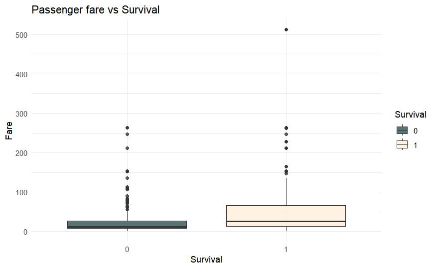

```r
#Boxplot for passenger fare and survival
ggplot(my_data, aes(x = factor(Survived), y = Fare, fill = factor(Survived))) +
  geom_boxplot(alpha = 0.8) +
  labs(title = "Passenger fare vs Survival",
       x = "Survival",
       y = "Fare",
       fill = "Survival") +
   scale_fill_manual(values = c("0" = "darkslategrey", "1" = "antiquewhite1")) +
  theme_minimal()
```

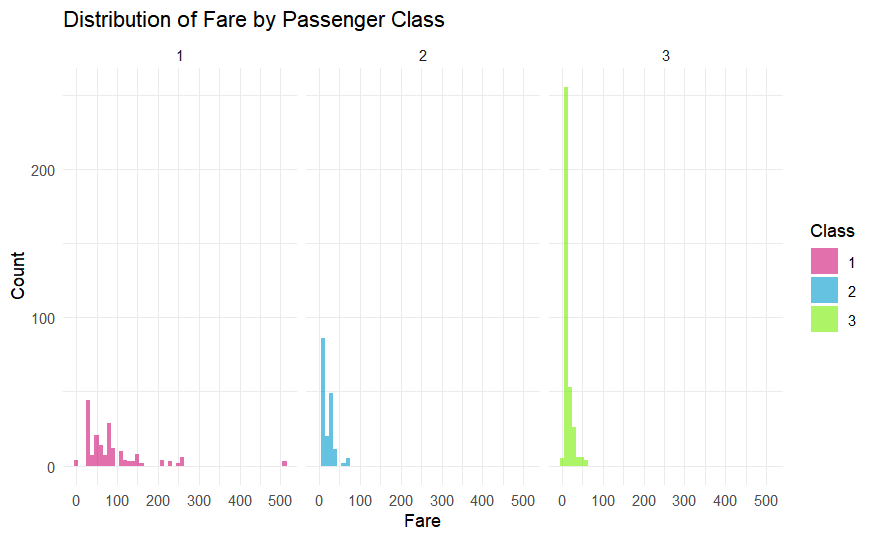

```r
#Distribution of fare by passenger class
ggplot(my_data, aes(x = Fare, fill = factor(Pclass))) +
  geom_histogram(binwidth = 10, alpha = 0.6, position = "identity") +
  facet_wrap(~ Pclass) +
  labs(
    title = "Distribution of Fare by Passenger Class",
    x = "Fare",
    y = "Count",
    fill = "Class") +
   scale_fill_manual(values = c("1" = "deeppink3", "2" = "deepskyblue3", "3" = "chartreuse2")) +
 theme_minimal()
```

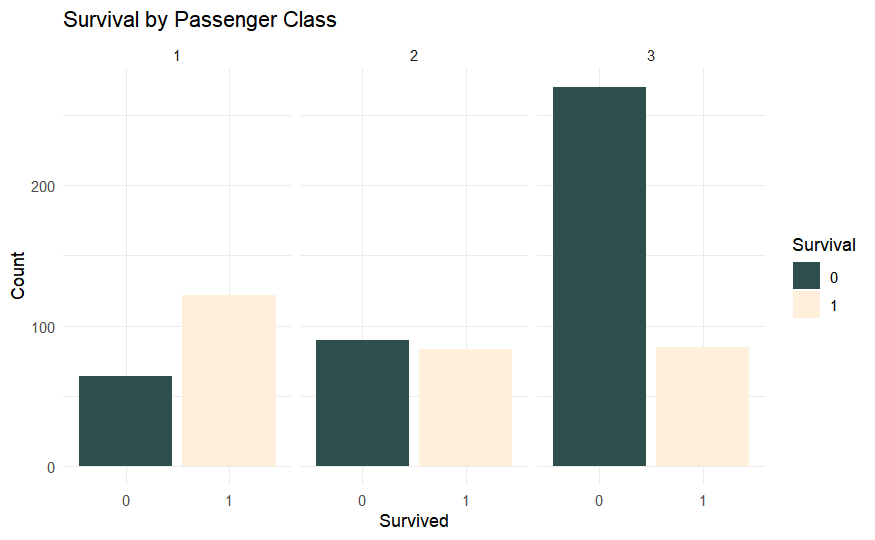

```r
#Survival by passenger class
ggplot(my_data, aes(x = factor(Survived), fill = factor(Survived))) +
  geom_bar() +
  facet_wrap(~ Pclass) +
  labs(
    title = "Survival by Passenger Class",
    x = "Survived",
    y = "Count",
    fill = "Survival"
  ) +
  scale_fill_manual(values = c("0" = "darkslategrey", "1" = "antiquewhite1")) +
  theme_minimal()
```

# Clustering

I decide to work on 2 continuous variables (`Age` and `Fare`) to visualize the data points and their cluster membership.

After I specify the variables of interest and the number of cluster centers, I print these centers for my model (two vectors with 2 coordinates)

Then, I am visualizing a graph via *ggplot* and show the centers. Next, I am standardizing the inputs by centering each variable on its mean and scaling by its standard deviation.

In the end I am visualizing the graph again.

```r
set.seed(1234)
dt_kmeans <- my_data[, c("Age", "Fare")]
model_kmeans <- kmeans(dt_kmeans, centers = 2)

model_kmeans$centers
```

```
       Age      Fare
1 29.56774  23.82088
2 31.60696 192.59855
```

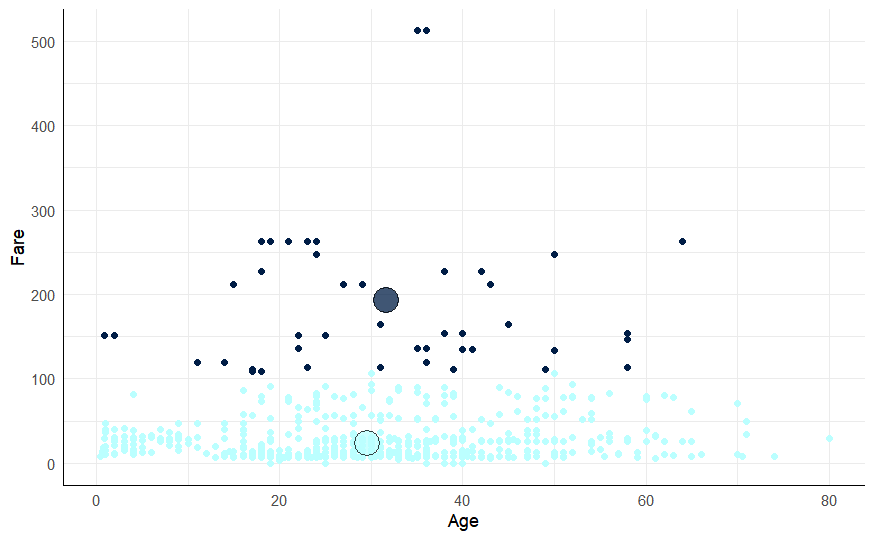

```r
ggplot(data=dt_kmeans, aes(x=Age, y=Fare, color=as.factor(model_kmeans$cluster))) +
  geom_point() +
  geom_point(data=data.frame(model_kmeans$centers),
             shape="circle filled",
             size=7,
             color="#000000",
             fill=c("#bbffff","#001d46"),
             alpha=0.75) +
  guides(
    color="none") +
  scale_color_manual(values=c("#bbffff","#001d46")) +
  labs(
    x="Age",
    y= "Fare") +
  theme_minimal() +
  theme(axis.line = element_line(color = "#000000"))
```

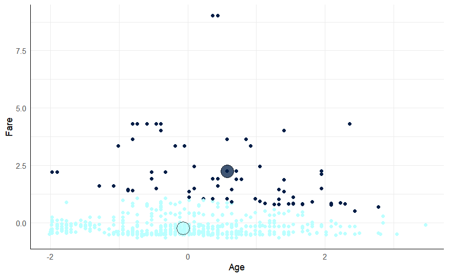

```r
#Standardizing the inputs
dt_kmeans_scaled <- data.table(scale(dt_kmeans))

model_kmeans_scaled <- kmeans(dt_kmeans_scaled, centers = 2)

ggplot(data=dt_kmeans_scaled, aes(x=Age, y=Fare, color=as.factor(model_kmeans_scaled$cluster))) +
  geom_point() +
  geom_point(data=data.frame(model_kmeans_scaled$centers),
             shape="circle filled",
             size=7,
             color="#000000",
             fill=c("#001d46","#bbffff"),
             alpha=0.75) +
  guides(
    color="none") +
  scale_color_manual(values=c("#001d46","#bbffff")) +
  labs(
    x="Age",
    y= "Fare") +
  theme_minimal() +
  theme(axis.line = element_line(color = "#000000"))
```

# Logistic regression

In this section I run a logistic regression by using the R base function *glm* for my training set. `Survived` is my target variable.

Then, I checked the β vectors by looking at the coefficients to get a feeling of the impact that each variable has on the target variable. `First class` and `Sex` are some of the most influential variables. `First class` has a positive relationship with the target variable while `Sex` has a negative relationship.

```r
model_logit <-glm(Survived ~ FirstClass + SecondClass + Sex + Age + SibSp + Parch + Fare + Cherbourg + Queenstown,
                 data = dt_training, family = binomial)

coef(model_logit)
```

```
(Intercept)  FirstClass SecondClass         Sex         Age       SibSp       Parch        Fare   Cherbourg  Queenstown
 1.67128444  2.52893297  1.16172761 -2.63663280 -0.04439066 -0.38009991 -0.03488646  0.00147113  0.13275428 -0.72195824
```

```r
#Class Probabilities
head(model_logit$fitted.values)
```

```
         1          2          3          4          5          6
0.83403070 0.73346424 0.29035584 0.30885425 0.76730088 0.08866698
```

```r
#Decision rule
dt_training[, k_pred := ifelse(model_logit$fitted.values > 0.5, 1, 0)]
head(dt_training$k_pred)
```

```
[1] 1 1 0 0 1 0
```

```r
#Accuracy of the model
mean(dt_training$k_pred == dt_training$Survived)
```

```
[1] 0.8091068
```

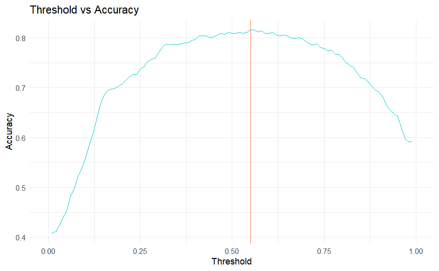

```r
#Increasing the accuracy of logistic regression
thresholds <- seq(0.01, 0.99, by = 0.01)


threshold_results <- data.frame(Threshold = thresholds, Accuracy = numeric(length(thresholds)))

#Loop
for (i in seq_along(thresholds)) {
  predictions <- ifelse(model_logit$fitted.values > thresholds[i], 1, 0)
  accuracy <- mean(predictions == dt_training$Survived)
  threshold_results$Accuracy[i] <- accuracy
}

#Storing the threshold that maximizes accuracy
optimal_threshold <- threshold_results$Threshold[which.max(threshold_results$Accuracy)]


#Thresholds vs accuracy plot
ggplot(threshold_results, aes(x = Threshold, y = Accuracy)) +
  geom_line(color = "cyan3") +
  labs(x = "Threshold", y = "Accuracy", title = "Threshold vs Accuracy") +
  geom_vline(xintercept = optimal_threshold, color = "coral") +
  xlim(0, 1)+
  theme_minimal()
```

```r
model_logit_2 <-glm(Survived ~ FirstClass + SecondClass + Sex + Age + SibSp + Parch + Fare + Cherbourg + Queenstown,
                 data = dt_training, family = binomial)

coef(model_logit_2)
```

```
(Intercept)  FirstClass SecondClass         Sex         Age       SibSp       Parch        Fare   Cherbourg  Queenstown
 1.67128444  2.52893297  1.16172761 -2.63663280 -0.04439066 -0.38009991 -0.03488646  0.00147113  0.13275428 -0.72195824
```

```r
head(model_logit_2$fitted.values)
```

```
         1          2          3          4          5          6
0.83403070 0.73346424 0.29035584 0.30885425 0.76730088 0.08866698
```

```r
dt_training[, k_pred_2 := ifelse(model_logit_2$fitted.values > optimal_threshold, 1, 0)]
head(dt_training$k_pred_2)
```

```
[1] 1 1 0 0 1 0
```

```r
#Accuracy of the new logistic model
mean(dt_training$k_pred_2 == dt_training$Survived)
```

```
[1] 0.8161121
```

# Tree model

The tree shows that `Sex` is a decisive variable in determining whether the passengers survive or not. Moreover, `Age`, `Passenger fare` and `Pclass` also play crucial roles.

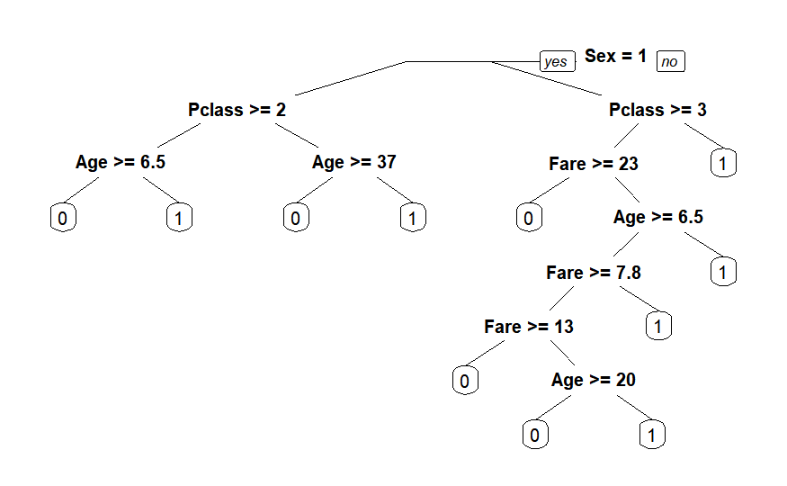

```r
model_tree <- rpart(data = dt_training, formula = Survived ~ Pclass + Sex + Age + SibSp + Parch + Fare + Embarked, method = "class")

prp(model_tree)
```

```r
mean(predict(model_tree, dt_training, type = "class")==dt_training$Survived)
```

```
[1] 0.8441331
```

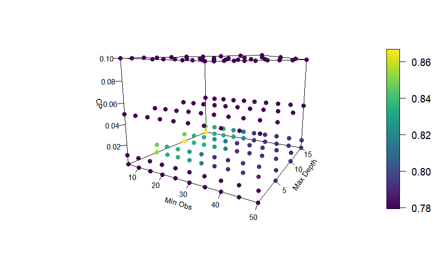

```r
# Create an empty data frame to store the results
results <- data.frame()

# Select the optimal parameter combination with the highest accuracy and store them
opt_params <- results[which.max(results$accuracy),]

min_obs <- seq(from = 5, to = 50, by = 5)
max_depth <- c(1, 5, 10, 15)
cp_val <- c(0.001, 0.01, 0.05, 0.1)

# Iterate over the combinations of min_obs, max_depth, and cp_val
for (i in 1:length(min_obs)) {
  for (j in 1:length(max_depth)) {
    for (k in 1:length(cp_val)) {
      # Build a decision tree model with the specified parameters
      model <- rpart(data = dt_training, formula = Survived ~ Pclass + Sex + Age + SibSp + Parch + Fare + Embarked,
                     method = "class",
                     cp = cp_val[k],
                     maxdepth = max_depth[j],
                     minbucket = min_obs[i])

      # Calculate the accuracy of the model predictions
      acc <- mean(predict(model, dt_training, type = "class") == dt_training$Survived)

      # Append the accuracy and parameter values to the results data frame
      results <- rbind(results, c(acc, min_obs[i], max_depth[j], cp_val[k]))
    }
  }
}

# Set column names for the results data frame
colnames(results) <- c("accuracy", "min_obs", "max_depth", "cp")

# Create a 3D scatter plot using scatter3D
plot3D::scatter3D(x = results$min_obs, y = results$max_depth, z = results$cp,
                  theta = 30, phi = 10,
                  xlab = "Min Obs", ylab = "Max Depth", zlab = "CP",
                  ticktype = "detailed",
                  pch = 19,
                  cex.axis = 0.75, cex.lab = 0.75, expand = 0.75,
                  colvar = results$accuracy, col = viridis(100))
```

```r
opt_params <- results[which.max(results$accuracy),]

model_tree_2 <- rpart(data=dt_training, formula = Survived ~ Pclass + Sex + Age + SibSp + Parch + Fare + Embarked,
                      method = "class",
                      cp = opt_params$cp,
                      maxdepth = opt_params$max_depth,
                      minbucket = opt_params$min_obs)

# Calculate the mean accuracy of the model predictions
mean(predict(model_tree_2, dt_training, type = "class") == dt_training$Survived)
```

```
[1] 0.8669002
```

# Neural Network

In this section I will build a neural network. Firstly, I set up the inputs and output as matrices. As the inputs are on different scales, I will include a normalization layer which takes the inputs and normalizes them. Then I retrieve the mean and standard deviation of the features using *adapt()* and store them with the layer. Then, I print each mean value which is calculated for X.

Next, I create the architecture of the neural network in *keras*. First, I add a pre-processing layer and then add 3 hidden layers with 16 units each and ReLu activation (to capture the non-linear relationships in order to allow the network to learn from complex data patterns). After that, I print out the summary of the model to show the structure of each layer and the number of parameters.

After configuring the layers and neurons, I set up the parameters for the algorithm using *compile()*. I indicate the loss function *MSE*, indicate *ADAM* as the optimizer and indicate *Accuracy* as the model evaluation metric which is very useful for the goal of my classification coursework.

Finally, I fit the model via *fit*, indicate once again the input data matrix and the target variable. Then, I specify the number of epochs for training, which in this case, the model will go through the entire dataset 500 times. In the end, I evaluate the model on the data and the accuracy is 89.3 %

```r
set.seed(12345)   # Set a seed for reproducibility

# Data setup
X <- as.matrix(dt_training[, c("FirstClass", "SecondClass", "ThirdClass", "Sex", "Age", "SibSp", "Parch", "Fare", "Southhampton", "Cherbourg", "Queenstown")])
y <- dt_training$Survived



normalize <- layer_normalization()   # Create a normalization layer
normalize %>% adapt(X)   # Adapt the normalization layer to the data

print(normalize$mean)   # Print the mean values used for normalization
```

```
tf.Tensor(
[[ 0.26795098  0.2364273   0.49562177  0.62697023 29.544937    0.5148862
   0.45183888 34.98491     0.77933466  0.18038532  0.03677759]], shape=(1, 11), dtype=float32)
```

```r
model_neural <- keras_model_sequential()   # Create a sequential model

model_neural %>%

  # L1: Pre-processing
  normalize() %>%

  layer_dense(name = "HiddenLayer_1", units = 16, activation = 'relu') %>%   # Add a hidden layer with 16 units and ReLU activation
  layer_dense(name = "HiddenLayer_2", units = 16, activation = 'relu') %>%   # Add a second hidden layer with 16 units and ReLU activation
  layer_dense(name = "HiddenLayer_3", units = 16, activation = 'relu') %>%   # Add a third hidden layer with 16 units and ReLU activation

   layer_dense(name = "OutputLayer", units = 1)   # Add an output layer with 1 unit

summary(model_neural)   # Print the summary of the model
```

```
Model: "sequential_2"
__________________________________________________________________________________________________________________________
 Layer (type)                                    Output Shape                                 Param #          Trainable
==========================================================================================================================
 normalization_2 (Normalization)                 (None, 11)                                   23               Y
 HiddenLayer_1 (Dense)                           (None, 16)                                   192              Y
 HiddenLayer_2 (Dense)                           (None, 16)                                   272              Y
 HiddenLayer_3 (Dense)                           (None, 16)                                   272              Y
 OutputLayer (Dense)                             (None, 1)                                    17               Y
==========================================================================================================================
Total params: 776 (3.04 KB)
Trainable params: 753 (2.94 KB)
Non-trainable params: 23 (96.00 Byte)
__________________________________________________________________________________________________________________________
```

```r
model_neural %>% compile(
  loss = "MSE",
  optimizer = "adam",
  metrics = "Accuracy"
)   # Compile the model with accuracy as a metric

model_neural %>% fit(
  x = X,
  y = y,
  epochs = 500,
  verbose = 0
)   # Train the model on the data for 500 epochs

# model_neural$layers[[2]]$kernel   # Print the kernel (weights) of the second layer
# model_neural$layers[[3]]$kernel   # Print the kernel (weights) of the third layer
# model_neural$layers[[4]]$kernel   # Print the kernel (weights) of the fourth layer


model_neural %>% evaluate(X, y, verbose = 0)
```

```
      loss   Accuracy
0.07369112 0.89316988
```

# Ensemble methods

```r
formula <- Survived ~ FirstClass + SecondClass + Sex + Age + SibSp + Parch + Fare + Cherbourg + Queenstown


model_ensemble <- randomForest(formula,
                                       data=dt_training,
                                       mtry=9,
                                       ntree=500)
print(model_ensemble)
```

```
Call:
 randomForest(formula = formula, data = dt_training, mtry = 9,      ntree = 500)
               Type of random forest: regression
                     Number of trees: 500
No. of variables tried at each split: 9

          Mean of squared residuals: 0.1440892
                    % Var explained: 40.35
```

```r
data.table(
  actual = dt_training$Survived,
  prediction = predict(model_ensemble, newdata = dt_training))
```

| actual | prediction |
| --- | --- |
| 1 | 1.000000e+00 |
| 1 | 9.165333e-01 |
| 0 | 1.173667e-01 |
| 0 | -8.981704e-17 |
| 0 | 2.340333e-01 |
| 0 | 6.280000e-02 |
| 0 | 1.900000e-02 |
| 0 | 1.622667e-01 |
| 0 | 3.430000e-02 |
| 0 | 2.789333e-01 |

[output cut: 561 more lines]

# PCA - Principle Components Analysis

Now I will use PCA to reduce the number of inputs (dimensions) in my models with minimal information loss. Basically, PCA looks for a new coordinate system whose basis vectors are aligned with the directions of the highest variance in the data. I could then drop the new basis vectors in the order of the variance they capture. Each PC coordinate is a linear combination of the original variables.

I start with standardizing the variables first to put them on equal footing. Then, to conduct PCA I will use a library which decomposes the covariance matrix and supplies other fundamental outputs (*prcomp*). The model output allows to investigate my 9 principle components. I apply *summary()* function in order to find the share that each PC contributes to explaining the variance of the data in descending order of the eigenvalues. After that, I use *fviz* functionality of *factoextra* to produce a scree plot of the information that *summary* function provided. By looking at the plot, I notice that my 4 first PCA can explain 66.1 % of the data.

I use *model_pca$rotation,2* to find the eigenvectors so I can then investigate how my original variables contribute to the PCs. They essentially contribute the coefficients to the linear combination of the variables that produce the PCs. All of the eigenvectors shown in the matrix V take each data point(passenger) to the PC coordinate system by multiplying the variables of one passenger with the matrix V.

Because of not much is gained in terms of dimensionality reduction if I keep all 9 PC coordinates, I will keep the first 4 PCs. As I said above, they capture almost 66 % of the variance of my data so it is enough to capture enough information.

In the end, I add PCA to my data in order to run the models later.

```r
#Standardize the variables
dt_pca <- data.table(scale(my_data[, c("Sex", "SibSp", "Age", "Parch", "Fare", "Queenstown", "Cherbourg", "FirstClass", "SecondClass")]))

model_pca <- prcomp(dt_pca)
summary(model_pca)
```

```
Importance of components:
                         PC1    PC2    PC3    PC4     PC5     PC6     PC7     PC8     PC9
Standard deviation     1.448 1.3216 1.0560 0.9927 0.93939 0.84914 0.78673 0.73802 0.53718
Proportion of Variance 0.233 0.1941 0.1239 0.1095 0.09805 0.08012 0.06877 0.06052 0.03206
Cumulative Proportion  0.233 0.4271 0.5510 0.6605 0.75853 0.83865 0.90742 0.96794 1.00000
```

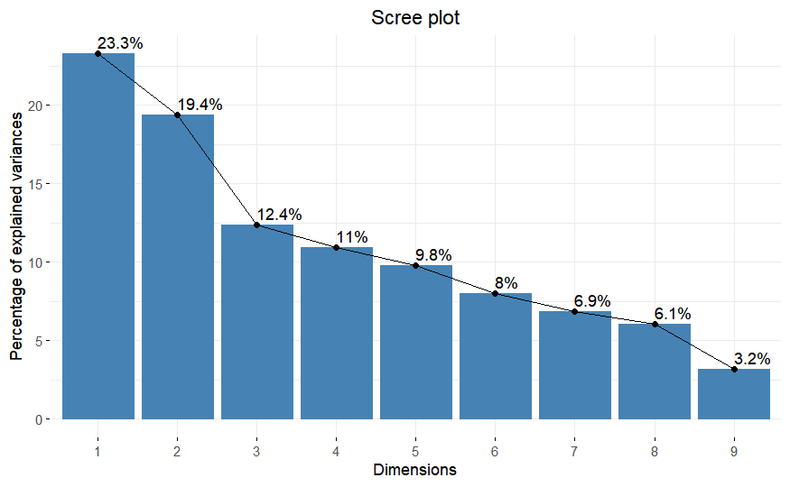

```r
#Scree plot to visualize the information about the variance of the data
fviz_eig(model_pca, addlabels = TRUE) +
         theme(plot.title = element_text(hjust = 0.5))
```

```r
#Matrix of (scaled) eigenvectors: V  ##They take each data point in the PC coordinate system by multiplying X with V
round(model_pca$rotation,2)
```

```
              PC1   PC2   PC3   PC4   PC5   PC6   PC7   PC8   PC9
Sex         -0.18  0.33  0.37 -0.50  0.34  0.51 -0.15 -0.25  0.09
SibSp        0.04 -0.56  0.18 -0.16  0.26  0.30  0.21  0.65 -0.03
Age          0.20  0.47 -0.11  0.35  0.46  0.03 -0.37  0.42 -0.28
Parch        0.12 -0.55 -0.08  0.05  0.30 -0.08 -0.67 -0.31  0.15
Fare         0.55 -0.13 -0.07  0.06  0.16  0.26  0.34 -0.43 -0.52
Queenstown  -0.09 -0.07  0.58  0.70 -0.20  0.33 -0.05 -0.10  0.07
Cherbourg    0.40  0.05 -0.11 -0.22 -0.65  0.39 -0.41  0.20 -0.04
FirstClass   0.60  0.15  0.06  0.05  0.16 -0.04  0.21  0.01  0.74
SecondClass -0.29 -0.02 -0.67  0.25  0.07  0.56  0.12 -0.06  0.26
```

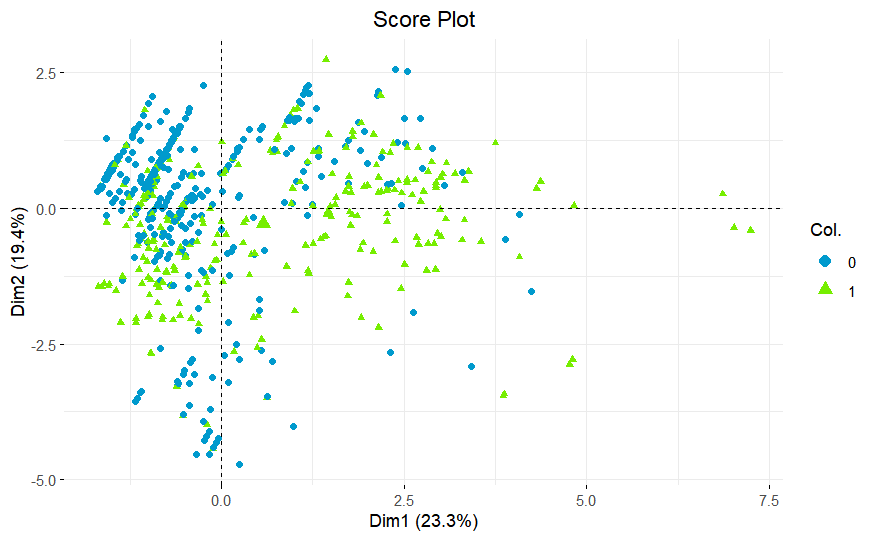

```r
#Score plot
fviz_pca_ind(model_pca,
             geom.ind = "point",
             col.ind = as.factor(my_data$Survived),
             palette = c("deepskyblue3", "chartreuse2")) +
  ggtitle("Score Plot") +
  theme(plot.title = element_text(hjust = 0.5))
```

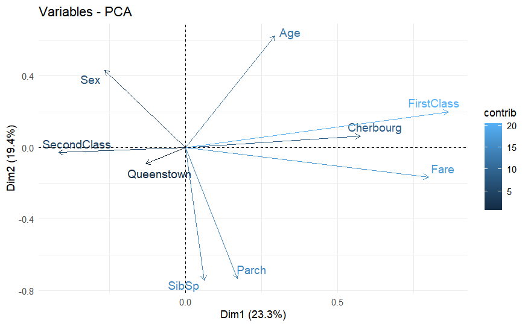

```r
#Loadings plot to investigate all the variables load onto the principle components
fviz_pca_var(model_pca,
             col.var="contrib",
             repel = TRUE) +
    theme_minimal()
```

```r
##Reduction of PCs from 9 to 4
# x * V_reduced
pcs <- as.matrix(dt_pca)[1,] %*%
  as.matrix(model_pca$rotation[,1:4])

#Add PCA to my data
pca <- as.data.frame(as.matrix(dt_pca) %*%
  as.matrix(model_pca$rotation))

dt_training <- cbind(dt_training, pca)
```

# Logistic regression - PCA

```r
#Run logistic regression with PCA
logistic_reg_pca <- glm(formula = Survived ~ PC1 + PC2 + PC3 + PC4,
                 data = dt_training, family = binomial(link = "logit"))

#summary of the model
summary(logistic_reg_pca)
```

```
Call:
glm(formula = Survived ~ PC1 + PC2 + PC3 + PC4, family = binomial(link = "logit"),
    data = dt_training)

Coefficients:
             Estimate Std. Error z value Pr(>|z|)
(Intercept) -0.328357   0.075921  -4.325 1.53e-05 ***
PC1         -0.042651   0.052884  -0.806    0.420
PC2         -0.013326   0.057480  -0.232    0.817
PC3         -0.044824   0.071939  -0.623    0.533
PC4          0.001484   0.076746   0.019    0.985
---
Signif. codes:  0 ‘***’ 0.001 ‘**’ 0.01 ‘*’ 0.05 ‘.’ 0.1 ‘ ’ 1

(Dispersion parameter for binomial family taken to be 1)

    Null deviance: 970.88  on 713  degrees of freedom
Residual deviance: 969.78  on 709  degrees of freedom
AIC: 979.78

Number of Fisher Scoring iterations: 4
```

```r
#Beta coefficients
coef(logistic_reg_pca)
```

```
 (Intercept)          PC1          PC2          PC3          PC4
-0.328357339 -0.042650800 -0.013326364 -0.044824055  0.001483802
```

```r
head(logistic_reg_pca$fitted.values)
```

```
        1         2         3         4         5         6
0.4194129 0.3938383 0.4265113 0.4038940 0.4180042 0.3947887
```

```r
#Apply decision rule
dt_training[, k_pred3 := ifelse(logistic_reg_pca$fitted.values > 0.5, 1, 0)]
head(dt_training$k_pred3)
```

```
[1] 0 0 0 0 0 0
```

```r
#Find the accuracy
mean(dt_training$k_pred3 == dt_training$Survived)
```

```
[1] 0.5812325
```

# Tree - PCA

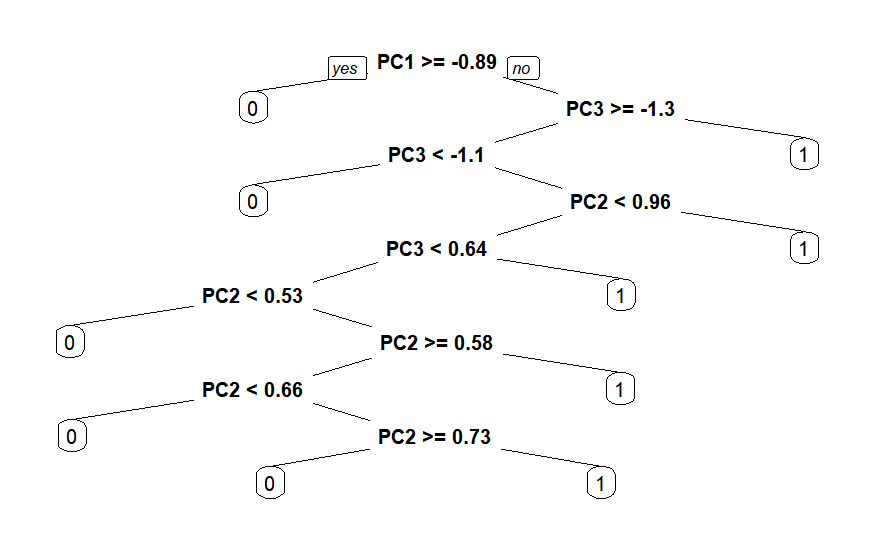

```r
#Tree model with PCA
tree_pca <- rpart(data = dt_training, formula = Survived ~ PC1 + PC2 + PC3 + PC4, method = "class")

prp(tree_pca)
```

```r
mean(predict(tree_pca, dt_training, type = "class")==dt_training$Survived)
```

```
[1] 0.6442577
```

# Neural Networks - PCA

```r
set.seed(12345)   # Set a seed for reproducibility

# Data setup
X <- as.matrix(dt_training[, c("PC1", "PC2", "PC3", "PC4")])
y <- dt_training$Survived


normalize_pca <- layer_normalization()   # Create a normalization layer
normalize_pca %>% adapt(X)   # Adapt the normalization layer to the data

print(normalize_pca$mean)   # Print the mean values used for normalization
```

```
tf.Tensor([[ 1.4901161e-08  4.1327439e-09 -5.1222742e-09 -9.3132257e-10]], shape=(1, 4), dtype=float32)
```

```r
neural_pca <- keras_model_sequential()   # Create a sequential model

neural_pca %>%

  # L1: Pre-processing
  normalize_pca() %>%

  layer_dense(name = "HiddenLayer_1", units = 16, activation = 'relu') %>%   # Add a hidden layer with 16 units and ReLU activation
  layer_dense(name = "HiddenLayer_2", units = 16, activation = 'relu') %>%   # Add a second hidden layer with 16 units and ReLU activation
  layer_dense(name = "HiddenLayer_3", units = 16, activation = 'relu') %>%   # Add a third hidden layer with 16 units and ReLU activation

   layer_dense(name = "OutputLayer", units = 1)   # Add an output layer with 1 unit

summary(neural_pca)   # Print the summary of the model
```

```
Model: "sequential_3"
__________________________________________________________________________________________________________________________
 Layer (type)                                    Output Shape                                 Param #          Trainable
==========================================================================================================================
 normalization_3 (Normalization)                 (None, 4)                                    9                Y
 HiddenLayer_1 (Dense)                           (None, 16)                                   80               Y
 HiddenLayer_2 (Dense)                           (None, 16)                                   272              Y
 HiddenLayer_3 (Dense)                           (None, 16)                                   272              Y
 OutputLayer (Dense)                             (None, 1)                                    17               Y
==========================================================================================================================
Total params: 650 (2.54 KB)
Trainable params: 641 (2.50 KB)
Non-trainable params: 9 (40.00 Byte)
__________________________________________________________________________________________________________________________
```

```r
neural_pca %>% compile(
  loss = "MSE",
  optimizer = "adam",
  metrics = "Accuracy"
)   # Compile the model with accuracy as a metric

neural_pca %>% fit(
  x = X,
  y = y,
  epochs = 500,
  verbose = 0
)   # Train the model on the data for 500 epochs




neural_pca %>% evaluate(X, y, verbose = 0)
```

```
     loss  Accuracy
0.1884817 0.6918768
```

```r
rm(list = c("X", "y"))
```

# Ensemble methods - PCA

```r
formula_pca <- Survived ~ PC1 + PC2 + PC3 + PC4

# Building a random forest model using the randomForest function
# mtry parameter is set to 9, which controls feature subsampling
# ntree parameter is set to 500, specifying the number of trees in the random forest
model_pca_ensemble <- randomForest(formula_pca,
                                       data=dt_training,
                                       mtry=9,
                                       ntree=500)
data.table(
  actual = dt_training$Survived,
  prediction = predict(model_pca_ensemble, newdata = dt_training))
```

| actual | prediction |
| --- | --- |
| 1 | 0.823800000 |
| 1 | 0.832600000 |
| 0 | 0.050966667 |
| 0 | 0.463133333 |
| 0 | 0.532709524 |
| 0 | 0.139066667 |
| 0 | 0.196800000 |
| 0 | 0.161500000 |
| 0 | 0.268700000 |
| 0 | 0.140366667 |

[output cut: 704 more lines]

# Cross - Validation

```r
dt_training[, Survived := as.factor(Survived)]


##Cross-validation for logistic regression w/o PCA
# Define the cross-validation control parameters
train_control <- trainControl(method = "cv", number = 5)  # 5-fold cross-validation

formula_glm <- Survived ~ FirstClass + SecondClass + Sex + Age + SibSp + Parch + Fare + Cherbourg + Queenstown

model_glm_cv <- train(formula_glm,
               data = dt_training,
               method = "glm",
               trControl = train_control)

print(model_glm_cv)
```

```
Generalized Linear Model

714 samples
  9 predictor
  2 classes: '0', '1'

No pre-processing
Resampling: Cross-Validated (5 fold)
Summary of sample sizes: 571, 571, 571, 571, 572
Resampling results:

  Accuracy   Kappa
  0.7941791  0.5728633
```

```r
##Cross-Validation for logistic regression with PCA

formula_glm_pca <- Survived ~ PC1 + PC2 + PC3 + PC4

model_glm_cv_pca <- train(formula_glm_pca,
               data = dt_training,
               method = "glm",
               trControl = train_control)

print(model_glm_cv_pca)
```

```
Generalized Linear Model

714 samples
  4 predictor
  2 classes: '0', '1'

No pre-processing
Resampling: Cross-Validated (5 fold)
Summary of sample sizes: 571, 572, 571, 571, 571
Resampling results:

  Accuracy   Kappa
  0.5812371  0
```

```r
##Cross-Validation for tree w/o PCA

formula_tree <- Survived ~ FirstClass + SecondClass + Sex + Age + SibSp + Parch + Fare + Cherbourg + Queenstown

model_tree_cv <- train(formula_tree,
                       data = dt_training,
                       method = "rpart",
                       trControl = train_control)

print(model_tree_cv)
```

```
CART

714 samples
  9 predictor
  2 classes: '0', '1'

No pre-processing
Resampling: Cross-Validated (5 fold)
Summary of sample sizes: 571, 571, 572, 571, 571
Resampling results across tuning parameters:

  cp          Accuracy   Kappa
  0.02675585  0.7885453  0.5633203
  0.03010033  0.7843199  0.5540013
  0.47491639  0.6903280  0.3011491

Accuracy was used to select the optimal model using the largest value.
The final value used for the model was cp = 0.02675585.
```

```r
##Cross-Validation for tree with PCA

formula_tree_pca <- Survived ~ PC1 + PC2 + PC3 + PC4

model_tree_cv_pca <- train(formula_tree_pca,
                       data = dt_training,
                       method = "rpart",
                       trControl = train_control)

print(model_tree_cv_pca)
```

```
CART

714 samples
  4 predictor
  2 classes: '0', '1'

No pre-processing
Resampling: Cross-Validated (5 fold)
Summary of sample sizes: 571, 572, 571, 571, 571
Resampling results across tuning parameters:

  cp           Accuracy   Kappa
  0.008361204  0.5224564  -0.01078122
  0.012263099  0.5574215   0.02563865
  0.025083612  0.5532355  -0.02013445

Accuracy was used to select the optimal model using the largest value.
The final value used for the model was cp = 0.0122631.
```

```r
##Cross-Validation for neural networks w/o PCA
formula_nn <- Survived ~ FirstClass + SecondClass + Sex + Age + SibSp + Parch + Fare + Cherbourg + Queenstown


model_nn_cv <- train(formula_nn,
                     data = dt_training,
                     method = "nnet",
                     trControl = train_control)
# Print the model results
print(model_nn_cv)
```

```
Neural Network

714 samples
  9 predictor
  2 classes: '0', '1'

No pre-processing
Resampling: Cross-Validated (5 fold)
Summary of sample sizes: 571, 571, 571, 572, 571
Resampling results across tuning parameters:

  size  decay  Accuracy   Kappa
  1     0e+00  0.6808529  0.2559543
  1     1e-04  0.6357825  0.1375351
  1     1e-01  0.7983158  0.5742551
  3     0e+00  0.8081257  0.5933359
  3     1e-04  0.8010637  0.5909562
  3     1e-01  0.8039003  0.5846703
  5     0e+00  0.8053088  0.5931979
  5     1e-04  0.7717916  0.5215634
  5     1e-01  0.8080961  0.5957533

Accuracy was used to select the optimal model using the largest value.
The final values used for the model were size = 3 and decay = 0.
```

```r
##Cross-Validation for neural networks with PCA
formula_nn_pca <- Survived ~ PC1 + PC2 + PC3 + PC4

model_nn_cv_pca <- train(formula_nn_pca,
                     data = dt_training,
                     method = "nnet",
                     trControl = train_control)
print(model_nn_cv_pca)
```

```
Neural Network

714 samples
  4 predictor
  2 classes: '0', '1'

No pre-processing
Resampling: Cross-Validated (5 fold)
Summary of sample sizes: 571, 571, 571, 572, 571
Resampling results across tuning parameters:

  size  decay  Accuracy   Kappa
  1     0e+00  0.5560622  -0.025181384
  1     1e-04  0.5714469  -0.007223965
  1     1e-01  0.5686497  -0.017742469
  3     0e+00  0.5434354  -0.016380679
  3     1e-04  0.5420762  -0.045853321
  3     1e-01  0.5518172  -0.018203543
  5     0e+00  0.5378312  -0.009850631
  5     1e-04  0.5378509  -0.007676273
  5     1e-01  0.5546144   0.004253407

Accuracy was used to select the optimal model using the largest value.
The final values used for the model were size = 1 and decay = 1e-04.
```

```r
##Cross-Validation for ensemble methods without PCA
formula_rf <- Survived ~ FirstClass + SecondClass + Sex + Age + SibSp + Parch + Fare + Cherbourg + Queenstown


model_rf_cv <- train(formula_rf,
                     data = dt_training,
                     method = "rf",
                     trControl = train_control)

# Print the model results
print(model_rf_cv)
```

```
Random Forest

714 samples
  9 predictor
  2 classes: '0', '1'

No pre-processing
Resampling: Cross-Validated (5 fold)
Summary of sample sizes: 572, 571, 571, 571, 571
Resampling results across tuning parameters:

  mtry  Accuracy   Kappa
  2     0.8361174  0.6559299
  5     0.8445090  0.6789105
  9     0.8431006  0.6773056

Accuracy was used to select the optimal model using the largest value.
The final value used for the model was mtry = 5.
```

```r
##Cross-Validation for ensemble methods with PCA
formula_rf_pca <- Survived ~ PC1 + PC2 + PC3 + PC4


model_rf_cv_pca <- train(formula_rf_pca,
                     data = dt_training,
                     method = "rf",
                     trControl = train_control)

print(model_rf_cv_pca)
```

```
Random Forest

714 samples
  4 predictor
  2 classes: '0', '1'

No pre-processing
Resampling: Cross-Validated (5 fold)
Summary of sample sizes: 571, 571, 571, 572, 571
Resampling results across tuning parameters:

  mtry  Accuracy   Kappa
  2     0.5560229  0.06924417
  3     0.5518270  0.06353369
  4     0.5574510  0.07533078

Accuracy was used to select the optimal model using the largest value.
The final value used for the model was mtry = 4.
```

```r
accuracy_table <- data.table(
  Model = c("Logistic Regression", "Logistic Regression PCA",
            "Tree", "Tree PCA",
            "Neural network", "Neural Network PCA",
            "Random Forest", "Random Forest PCA"
            ),
  Accuracy = c(
    model_glm_cv$results$Accuracy[1],
    model_glm_cv_pca$results$Accuracy[1],
    model_tree_cv$results$Accuracy[1],
    model_tree_cv_pca$results$Accuracy[1],
    model_nn_cv$results$Accuracy[1],
    model_nn_cv_pca$results$Accuracy[1],
    model_rf_cv$results$Accuracy[1],
    model_rf_cv_pca$results$Accuracy[1])
 )

print(accuracy_table)
```

| Model | Accuracy |
| --- | --- |
| Logistic Regression | 0.7941791 |
| Logistic Regression PCA | 0.5812371 |
| Tree | 0.7885453 |
| Tree PCA | 0.5224564 |
| Neural network | 0.6808529 |
| Neural Network PCA | 0.5560622 |
| Random Forest | 0.8361174 |
| Random Forest PCA | 0.5560229 |

# Test on the best model

```r
dt_test[, Survived := as.factor(Survived)]
predictions <- predict(model_rf_cv, newdata = dt_test)

accuracy <- mean(predictions == dt_test$Survived)
print(accuracy)
```

```
[1] 0.8111888
```